# Análisis de Componentes Principales

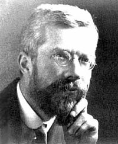

Fisher

En 1936, el biólogo y estadístico Ronald Fisher, recopila datos de 150 lirios (*Iris spp.*) para cuantificar la variación geográfica de estas flores en la Penínusula de Gaspé, en Canadá.

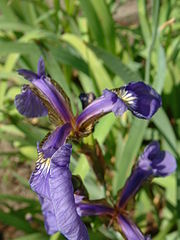

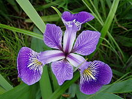

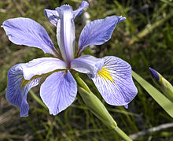

*Iris setosa*

*Iris versicolor*

*Iris virginica*

Vamos a analizar estos datos con componentes principales. Pero primero vamos a bajar el archivo del informe. Si no les funciona, copien la URL en el navegador y guarden el archivo.

```r
download.file("https://git.io/vHRvn", "Informe.Rmd")
```

Una vez hecho esto vamos a cargar los datos. Los mismos forman parte de los conjuntos de datos que R trae cargados por defecto. Estos datos pueden cargar en el espacio de trabajo usando la función `data()`

```r
data("iris")
```

Siempre es importante realizar un análisis exploratorio de los datos para verificar que no haya nada raro y también tener una idea de que distribución tienen. Lo más rápido y conveniente es realizar una matriz de gráficos.

```r
ggpairs(iris)
```

[output not shown]

¿Que variables tienen mayor correlación entre si? ¿Cuáles tienen menos?

El gráfico nos da mucha información, pero podría mejorarse. Si lo vemos así, parece que la distribución de largo y ancho de pétalos es bimodal ¡Pero tenemos tres especies! Seguramente, esto se debe a que cada especie tiene su propia distribución. Agregemos un poco de color al gráfico y veamos si es cierto.

```r
ggpairs(iris, aes(color = Species))
```

[output not shown]

¿Es cierto que la bimodalidad se debía a que cada especie tiene su propia distribución para las variables?

Los datos parecen estar bien, por lo que vamos a realizar el análisis de componentes principales. Recordemos que el objetivo de está técnica es crear nuevas variables (ejes) que resuman la mayor cantidad de variación de la datos. Y que cada eje es ortogonal al resto por lo que están totalmente incorrelados. En **R** existen varias funciones que realizan el análisis de componentes principales. Los detalles son un poco arcanos para este curso, pero basta decir que la que vamos a usar, `prcomp()` tiene resultados más precisos. Esta función tiene varios argumentos; entre los más importantes vamos a mencionar `center` un argumento lógico (VERDADERO o FALSO) que indica si las variables deben ser centradas, y `scale` también un argumento lógico que indica si las variables deben ser escaladas para que la varianza sea 1.

Si trabajamos con las variables sin escalar usamos la matriz de varianza-covarianza ¿Con qué matriz trabajamos si las usamos escaladas?

Vamos a empezar usando la matriz de varianza-covarianza. Primero creamos un nuevo conjunto de datos con solo los datos númericos. Para estas variables es recomendado aplicar el logaritmo para estabilizar las varianzas.

```r
iris_mat <- iris %>%
  select_if(is.numeric) %>%
  log

iris_pca <- prcomp(iris_mat, center = TRUE)
iris_pca
```

[output not shown]

Al llamar al objeto que contiene el resultado del ACP no devuelve un pequeño resumen. Los desvios estándar, es decir la raíz de los autovalores, y la matriz de autovectores. Comprobemos lo que vimos en teoría sobre esta matriz. Los vectores tienen longitud igual a 1. Así que si sumamos en filas o en columnas debería dar 1. Para facilitar los cálculos vamos a crear una función que eleve cada valor al cuadrado y los sume.

```r
sum_cuad <- function(x) sum(x^2)
```

La función se llama `sum_cuad`. Hacer una función es bastante simple en **R**. Con `function` se crea la función y se pone los argumentos que va a tener. En este caso solo `x`. Lo que va hacer la función va a tomar los valores que pongamos en x, elevarlos al cuadrado y luego sumarlos. Por ejemplo:

```r
sum_cuad(2)
```

```
## [1] 4
```

```r
sum_cuad(c(2, 4, 6, 8))
```

```
## [1] 120
```

Ahora que está lista la función, podemos usarla para sumar las columnas y las filas. Para sumar la primer columna, primero seleccionamos la matriz de rotación usando `$` y el nombre del objeto. Luego, entre corchetes la columna como las matrices tienen dos dimensiones (primero filas y luego columnas como en la notación matemática) y queremos todas las filas solo ponemos una `,` que indica que queremos todas las filas y luego un `1` que indica la primer columna.

```r
sum_cuad(iris_pca$rotation[, 1])
```

[output not shown]

## Ejercicio 2

Haga la suma para la segunda fila. ¿Cuanto debería dar cada una de las sumas marginales?

Si bien se puede hacer cada suma manualmente, resulta muy cansador y poco práctico. Para eso tenemos una computadora que haga el trabajo repetitivo por nosotros. Existe una función muy práctica, que puede aplicar otras funciones a las filas o columnas de un objeto. Los argumentos son `X` el objeto, `MARGIN` que es la marginal que queremos calcular 1=filas, 2=columnas:

```r
apply(iris_pca$rotation, 1, sum_cuad)
apply(iris_pca$rotation, 2, sum_cuad)
```

[output not shown]

## Ejercicio 3

Basados en los los resultados de la sumatorias por filas y por columnas. ¿Que matriz de autovectores están viendo?

Ahora vamos a escalar la matriz de autovectores por sus desvio estándar y volver a sumar en filas y columnas la matriz resultante.

```r
iris_UA <- iris_pca$rotation %*% diag(iris_pca$sdev)
apply(iris_UA, 2, sum_cuad)
apply(iris_UA, 1, sum_cuad)
```

[output not shown]

## Ejercicio 4

¿A que es igual la suma por filas en la matriz anterior? ¿Y la suma de las columnas? Utilizen la función `cov()` sobre los datos `iris_mat` ¿Con que coinciden los valores de diagonal? ¿Qué son los valores de la diagonal? ¿Y si elevan al cuadrado los desvíos estándar del ACP?

Como vimos anteriormente, el simbolo `$` sirve para seleccionar los objetos de una lista. Seleccionemos solo los desvíos estándar:

```r
iris_pca$sdev
```

[output not shown]

## Ejercicio 5

¿Que porcentaje de la varianza explica cada eje principal? ¿Cómo se calcula?

Una forma directa de saber esto es usando la función `summary()`.

```r
summary(iris_pca)
```

[output not shown]

## Ejercicio 6

¿Que porcentaje de reconstrucción tiene cada una de las variables en los dos primeros ejes?

Resulta muy util verlo graficado. La función de base es `biplot()` pero no produce gráficos atractivos y es complicada de modificar. Por eso vamos a usar una especifica que usa el paquete `ggplot2`, como casi todos los gráficos que usamos anteriormente. La función `ggbiplot()` tiene varios argumentos, entre los más importantes `scale` que es algo complicado como está implementado pero resumiendo, si es `0` el gráfico corresponde a un *biplot de distancia* y si es `1` es un *biplot de correlación*. Empecemos por un biplot de correlación:

```r
g <- ggbiplot(iris_pca, obs.scale = 1, var.scale = 1,
              groups = iris$Species,
              ellipse = FALSE,
              circle = TRUE)
g <- g + scale_color_discrete(name = '')
g <- g + theme(legend.direction = 'horizontal',
               legend.position = 'top')
print(g)
```

[output not shown]

## Ejercicio 7

Observando el gráfico anterior. ¿Qué variables están más correlacionadas con el eje 1? ¿Qué variables lo están con el eje 2?

Ahora veamos como se ve el biplot de distancia:

```r
g <- ggbiplot(iris_pca, obs.scale = 0, var.scale = 0,
              groups = iris$Species,
              ellipse = FALSE,
              circle = TRUE)
g <- g + scale_color_discrete(name = '')
g <- g + theme(legend.direction = 'horizontal',
               legend.position = 'top')
print(g)
```

[output not shown]

## Ejercicio 8

¿Qué puede concluir sobre las especies? ¿En que caracterísiticas se parecen? ¿Qué especies son más parecidas?

# Por su cuenta

Estandaricen los datos de Iris y vuelvan a trabajar sobre ellos:

```r
iris_z <- scale(iris_mat, center = TRUE, scale = TRUE)
```

Respondan las siguientes preguntas

## 1

Haga la suma para la segunda fila. ¿Cuanto debería dar cada una de las sumas marginales?

## 2

Basados en los los resultados de la sumatorias por filas y por columnas. ¿Que matriz de autovectores están viendo?

## 3

¿A que es igual la suma por filas en la matriz anterior? ¿Y la suma de las columnas? Utilizen la función `cor()` sobre los datos `iris_mat` ¿Con que coinciden los valores de diagonal? ¿Qué son los valores de la diagonal? ¿Y si elevan al cuadrado los desvíos estándar del ACP? ¿Como se diferencia esto de la parte donde trabajaron con las covarianzas?

## 4

¿Que porcentaje de la varianza explica cada eje principal? ¿Cómo se calcula?

## 5

¿Que porcentaje de reconstrucción tiene cada una de las variables en los dos primeros ejes?

## 6

Observando el gráfico anterior. ¿Qué variables están más correlacionadas con el eje 1? ¿Qué variables lo están con el eje 2?

## 7

¿Qué puede concluir sobre las especies? ¿En que caracterísiticas se parecen? ¿Qué especies son más parecidas?